# dsc90

## PROBLEM

### What can we learn about different hosts and areas? - Kaggle

```python
# !pip install --user arcgis==1.6.0
```

```python
import pandas as pd

import arcgis
from arcgis.gis import GIS
import pandas as pd
import numpy as np
import warnings
warnings.simplefilter(action='ignore', category=FutureWarning)
import geopandas as gpd
import matplotlib.pyplot as plt

gis = GIS(username='psheurpu_ucsd5')
print('Successfully logged in as: ' + gis.properties.user.username)
```

```
Enter password: ········
Successfully logged in as: psheurpu_ucsd5
```

```python
df = pd.read_csv('AB_NYC_2019.csv')
df.head()
```

|  | id | name | host_id | host_name | neighbourhood_group | neighbourhood | latitude | longitude | room_type | price | minimum_nights | number_of_reviews | last_review | reviews_per_month | calculated_host_listings_count | availability_365 |
| --- | --- | --- | --- | --- | --- | --- | --- | --- | --- | --- | --- | --- | --- | --- | --- | --- |
| 0 | 2539 | Clean & quiet apt home by the park | 2787 | John | Brooklyn | Kensington | 40.64749 | -73.97237 | Private room | 149 | 1 | 9 | 2018-10-19 | 0.21 | 6 | 365 |
| 1 | 2595 | Skylit Midtown Castle | 2845 | Jennifer | Manhattan | Midtown | 40.75362 | -73.98377 | Entire home/apt | 225 | 1 | 45 | 2019-05-21 | 0.38 | 2 | 355 |
| 2 | 3647 | THE VILLAGE OF HARLEM....NEW YORK ! | 4632 | Elisabeth | Manhattan | Harlem | 40.80902 | -73.94190 | Private room | 150 | 3 | 0 | NaN | NaN | 1 | 365 |
| 3 | 3831 | Cozy Entire Floor of Brownstone | 4869 | LisaRoxanne | Brooklyn | Clinton Hill | 40.68514 | -73.95976 | Entire home/apt | 89 | 1 | 270 | 2019-07-05 | 4.64 | 1 | 194 |
| 4 | 5022 | Entire Apt: Spacious Studio/Loft by central park | 7192 | Laura | Manhattan | East Harlem | 40.79851 | -73.94399 | Entire home/apt | 80 | 10 | 9 | 2018-11-19 | 0.10 | 1 | 0 |

```python
df.dropna(subset=['longitude','latitude'], how='any', inplace=True)
sdf = pd.DataFrame.spatial.from_xy(df, 'longitude', 'latitude')
sdf_less500 = sdf[sdf['price'] <= 500]
```

```python
df.isnull().mean()
```

```
id                                0.000000
name                              0.000327
host_id                           0.000000
host_name                         0.000429
neighbourhood_group               0.000000
neighbourhood                     0.000000
latitude                          0.000000
longitude                         0.000000
room_type                         0.000000
price                             0.000000
minimum_nights                    0.000000
number_of_reviews                 0.000000
last_review                       0.205583
reviews_per_month                 0.205583
calculated_host_listings_count    0.000000
availability_365                  0.000000
SHAPE                             0.000000
dtype: float64
```

```python
priceOnlytest = sdf_less500[['price', 'longitude', 'latitude']]
```

```python
#
# airbnb_less500_layer = priceOnlytest.spatial.to_featurelayer('airbnbNYCLessThan500_priceonly', gis=gis)
```

```python
sdf_less500_layer = gis.content.get('ded66366841448f8bf0d43b07707dfe6')#.layers[0].query().sdf
```

```python
# pd.DataFrame.spatial.from_layer(airbnb_less500_layer)
```

```python
sdf = pd.DataFrame.spatial.from_xy(df, 'longitude', 'latitude')
# airbnb_layer = sdf.spatial.to_featurelayer('airbnbNYC', gis=gis)
```

```python
m2 = gis.map('New York, NY')
m2.add_layer(sdf_less500_layer)
m2
```

[figure not shown]

```python
from IPython.display import Image
from IPython.core.display import HTML
Image(url= "https://i.imgur.com/tbpT11D.png")
```

[figure not shown]

```python
# sdf_less500 = sdf[sdf['price'] < 500].copy()
# len(sdf)
```

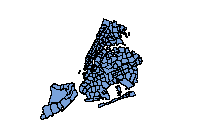

[**NYC_ZIP_CODE_2014**](https://UCSDOnline.maps.arcgis.com/home/item.html?id=7eeb21c12d884ce6ad33fd33b9b26d23)

[figure not shown]

Feature Layer Collection by prattcenter  
Last Modified: December 11, 2017  
0 comments, 2,839 views

```python
zipcodes = gis.content.get('7eeb21c12d884ce6ad33fd33b9b26d23')
zipcodes
```

```python
m1 = gis.map('New York, NY')
m1.add_layer(zipcodes)
m1.add_layer(sdf_less500_layer)

m1
```

[figure not shown]

```python
Image(url= "https://i.imgur.com/j9ZBu4T.png")
```

[figure not shown]

```python
zipcodes_layer = zipcodes.layers[0]
zipcodes_layer_sdf = pd.DataFrame.spatial.from_layer(zipcodes_layer)
zipcodes_layer_sdf.head()
```

|  | FID | ZIPCODE | BLDGZIP | PO_NAME | POPULATION | AREA | STATE | COUNTY | ST_FIPS | CTY_FIPS | URL | SHAPE_AREA | SHAPE_LEN | SHAPE |
| --- | --- | --- | --- | --- | --- | --- | --- | --- | --- | --- | --- | --- | --- | --- |
| 0 | 1 | 11436 | 0 | Jamaica | 18681 | 2.269930e+07 | NY | Queens | 36 | 081 | http://www.usps.com/ | 0 | 0 | {"rings": [[[-8216029.62387717, 4965683.981392... |
| 1 | 2 | 11213 | 0 | Brooklyn | 62426 | 2.963100e+07 | NY | Kings | 36 | 047 | http://www.usps.com/ | 0 | 0 | {"rings": [[[-8230673.6134866, 4965217.2196151... |
| 2 | 3 | 11212 | 0 | Brooklyn | 83866 | 4.197210e+07 | NY | Kings | 36 | 047 | http://www.usps.com/ | 0 | 0 | {"rings": [[[-8226837.9537665, 4963912.3812964... |
| 3 | 4 | 11225 | 0 | Brooklyn | 56527 | 2.369863e+07 | NY | Kings | 36 | 047 | http://www.usps.com/ | 0 | 0 | {"rings": [[[-8232964.07157416, 4963885.549142... |
| 4 | 5 | 11218 | 0 | Brooklyn | 72280 | 3.686880e+07 | NY | Kings | 36 | 047 | http://www.usps.com/ | 0 | 0 | {"rings": [[[-8234534.56010564, 4960941.753543... |

```python
# airbnb_layer
```

```python
from arcgis.features import summarize_data
col_summary = summarize_data.aggregate_points(point_layer = sdf_less500_layer,
                                            polygon_layer = zipcodes_layer,
                                            keep_boundaries_with_no_points=False,
                                            summary_fields=['price Mean'])
```

```python
less500_sdf = sdf_less500_layer.layers[0].query().sdf
less500_sdf.head()
```

|  | FID | id | name | host_id | host_name | neighbourh | neighbou_1 | latitude | longitude | room_type | price | minimum_ni | number_of_ | last_revie | reviews_pe | calculated | availabili | SHAPE |
| --- | --- | --- | --- | --- | --- | --- | --- | --- | --- | --- | --- | --- | --- | --- | --- | --- | --- | --- |
| 0 | 1 | 2539 | Clean & quiet apt home by the park | 2787 | John | Brooklyn | Kensington | 40.64749 | -73.97237 | Private room | 149 | 1 | 9 | 2018-10-19 | 0.21 | 6 | 365 | {"x": -8234566.561171626, "y": 4960484.7412660... |
| 1 | 2 | 2595 | Skylit Midtown Castle | 2845 | Jennifer | Manhattan | Midtown | 40.75362 | -73.98377 | Entire home/apt | 225 | 1 | 45 | 2019-05-21 | 0.38 | 2 | 355 | {"x": -8235835.603366669, "y": 4976068.3121687... |
| 2 | 3 | 3647 | THE VILLAGE OF HARLEM....NEW YORK ! | 4632 | Elisabeth | Manhattan | Harlem | 40.80902 | -73.94190 | Private room | 150 | 3 | 0 | nan | NaN | 1 | 365 | {"x": -8231174.656287155, "y": 4984212.8378376... |
| 3 | 4 | 3831 | Cozy Entire Floor of Brownstone | 4869 | LisaRoxanne | Brooklyn | Clinton Hill | 40.68514 | -73.95976 | Entire home/apt | 89 | 1 | 270 | 2019-07-05 | 4.64 | 1 | 194 | {"x": -8233162.8223927235, "y": 4966010.228227... |
| 4 | 5 | 5022 | Entire Apt: Spacious Studio/Loft by central park | 7192 | Laura | Manhattan | East Harlem | 40.79851 | -73.94399 | Entire home/apt | 80 | 10 | 9 | 2018-11-19 | 0.10 | 1 | 0 | {"x": -8231407.314022913, "y": 4982667.2079007... |

```python
col_agg_fc = col_summary['aggregated_layer']
col_agg_fset = col_agg_fc.query()
col_summary['aggregated_layer'].query().sdf.head()
```

|  | FID | Point_Count | ZIPCODE | BLDGZIP | PO_NAME | POPULATION | AREA | STATE | COUNTY | ST_FIPS | CTY_FIPS | URL | MEAN_price | AnalysisArea | SHAPE |
| --- | --- | --- | --- | --- | --- | --- | --- | --- | --- | --- | --- | --- | --- | --- | --- |
| 0 | 1 | 43 | 11436 | 0 | Jamaica | 18681 | 2.269930e+07 | NY | Queens | 36 | 081 | http://www.usps.com/ | 3171281 | 0.814230 | {"rings": [[[-8216029.6239, 4965683.981399998]... |
| 1 | 2 | 550 | 11213 | 0 | Brooklyn | 62426 | 2.963100e+07 | NY | Kings | 36 | 047 | http://www.usps.com/ | -19402600 | 1.062871 | {"rings": [[[-8230673.613500001, 4965217.21959... |
| 2 | 3 | 89 | 11212 | 0 | Brooklyn | 83866 | 4.197210e+07 | NY | Kings | 36 | 047 | http://www.usps.com/ | -24112866 | 1.505548 | {"rings": [[[-8226837.9538, 4963912.381300002]... |
| 3 | 4 | 648 | 11225 | 0 | Brooklyn | 56527 | 2.369863e+07 | NY | Kings | 36 | 047 | http://www.usps.com/ | -33125644 | 0.850075 | {"rings": [[[-8232964.071599999, 4963885.54909... |
| 4 | 5 | 331 | 11218 | 0 | Brooklyn | 72280 | 3.686880e+07 | NY | Kings | 36 | 047 | http://www.usps.com/ | -64603479 | 1.322488 | {"rings": [[[-8234534.5601, 4960941.7535], [-8... |

## Ran into corrupted price errors after converting to feature layer :'(

I think due to how many rows there are?

```python
# proportion of nulls per column
df.isnull().mean()
```

```
id                                0.000000
name                              0.000327
host_id                           0.000000
host_name                         0.000429
neighbourhood_group               0.000000
neighbourhood                     0.000000
latitude                          0.000000
longitude                         0.000000
room_type                         0.000000
price                             0.000000
minimum_nights                    0.000000
number_of_reviews                 0.000000
last_review                       0.205583
reviews_per_month                 0.205583
calculated_host_listings_count    0.000000
availability_365                  0.000000
dtype: float64
```

```python
count_by_neighbor = df.groupby('neighbourhood_group').agg('count').reset_index()
```

```python
nyc = gpd.read_file(gpd.datasets.get_path('nybb'))

nyc.rename(columns={'BoroName':'neighbourhood_group'}, inplace=True)

merge_airbnb_nyc = nyc.merge(count_by_neighbor, on='neighbourhood_group')
```

```python
merge_airbnb_nyc.head()
```

|  | BoroCode | neighbourhood_group | Shape_Leng | Shape_Area | geometry | id | name | host_id | host_name | neighbourhood | latitude | longitude | room_type | price | minimum_nights | number_of_reviews | last_review | reviews_per_month | calculated_host_listings_count | availability_365 |
| --- | --- | --- | --- | --- | --- | --- | --- | --- | --- | --- | --- | --- | --- | --- | --- | --- | --- | --- | --- | --- |
| 0 | 5 | Staten Island | 330470.010332 | 1.623820e+09 | MULTIPOLYGON (((970217.022 145643.332, 970227.... | 373 | 373 | 373 | 373 | 373 | 373 | 373 | 373 | 373 | 373 | 373 | 314 | 314 | 373 | 373 |
| 1 | 4 | Queens | 896344.047763 | 3.045213e+09 | MULTIPOLYGON (((1029606.077 156073.814, 102957... | 5666 | 5666 | 5666 | 5664 | 5666 | 5666 | 5666 | 5666 | 5666 | 5666 | 5666 | 4574 | 4574 | 5666 | 5666 |
| 2 | 3 | Brooklyn | 741080.523166 | 1.937479e+09 | MULTIPOLYGON (((1021176.479 151374.797, 102100... | 20104 | 20098 | 20104 | 20095 | 20104 | 20104 | 20104 | 20104 | 20104 | 20104 | 20104 | 16447 | 16447 | 20104 | 20104 |
| 3 | 1 | Manhattan | 359299.096471 | 6.364715e+08 | MULTIPOLYGON (((981219.056 188655.316, 980940.... | 21661 | 21652 | 21661 | 21652 | 21661 | 21661 | 21661 | 21661 | 21661 | 21661 | 21661 | 16632 | 16632 | 21661 | 21661 |
| 4 | 2 | Bronx | 464392.991824 | 1.186925e+09 | MULTIPOLYGON (((1012821.806 229228.265, 101278... | 1091 | 1090 | 1091 | 1090 | 1091 | 1091 | 1091 | 1091 | 1091 | 1091 | 1091 | 876 | 876 | 1091 | 1091 |

## What can we learn about different hosts and areas? - Kaggle

```
(905464.7390380859, 1075092.8783935546, 112485.76063504723, 280480.4142594267)
```

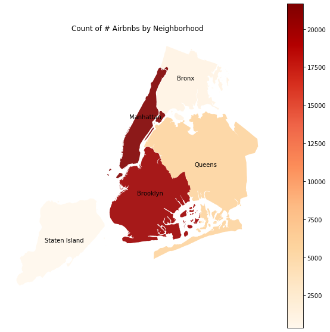

```python
fig,ax = plt.subplots(1,1, figsize=(10,10))
merge_airbnb_nyc.plot(column='id', alpha=.9, cmap='OrRd', ax=ax, legend=True)

merge_airbnb_nyc.apply(lambda x: ax.annotate(s=x.neighbourhood_group, xy=x.geometry.representative_point().coords[0], ha='center'), axis=1)
plt.title("Count of # Airbnbs by Neighborhood")
plt.axis('off')
```

### Brooklyn and Manhattan have the most Airbnb's! Are they the most popular places?

```
(905464.7390380859, 1075092.8783935546, 112485.76063504723, 280480.4142594267)
```

[figure not shown]

```python
rev_by_neighbor = df.groupby('neighbourhood_group').agg({'reviews_per_month' : 'mean'}).reset_index()
merge_airbnb_nyc_rev = nyc.merge(rev_by_neighbor, on='neighbourhood_group')

fig,ax = plt.subplots(1,1, figsize=(10,10))
merge_airbnb_nyc_rev.plot(column='reviews_per_month', cmap= 'OrRd', alpha=.9, ax=ax, legend=True)

merge_airbnb_nyc_rev.apply(lambda x: ax.annotate(s=x.neighbourhood_group, xy=x.geometry.representative_point().coords[0], ha='center'), axis=1)
plt.title("Median # Reviews/Mo by Neighborhood")
plt.axis('off')
```

### It seems like Staten Island, Bronx, and Queens are actually the most popular judging by avg number of reviews per month... What could be reasons why?

```
(905464.7390380859, 1075092.8783935546, 112485.76063504723, 280480.4142594267)
```

[figure not shown]

```python
price_by_neighbor = df.groupby('neighbourhood_group').agg({'price' : 'median'}).reset_index()
merge_airbnb_nyc_Price = nyc.merge(price_by_neighbor, on='neighbourhood_group')

fig,ax = plt.subplots(1,1, figsize=(10,10))
merge_airbnb_nyc_Price.plot(column='price', cmap= 'OrRd', alpha=.9, ax=ax, legend=True)

merge_airbnb_nyc_Price.apply(lambda x: ax.annotate(s=x.neighbourhood_group, xy=x.geometry.representative_point().coords[0], ha='center'), axis=1)
plt.title("Median Price of Airbnbs per Night, by Neighborhood")
plt.axis('off')
```

```python
import plotly.express as px
import plotly.figure_factory as ff
import plotly.graph_objects as go

data = px.data.gapminder()

fig = go.Figure()
df2 = df[df['price'] <= 500]

neighborhoods = ['Bronx', 'Staten Island', 'Queens', 'Brooklyn', 'Manhattan']

for group in neighborhoods:
    fig.add_trace(go.Violin(x=df2[df2['neighbourhood_group'] == group]['neighbourhood_group'],
                            y=df2[df2['neighbourhood_group'] == group]['price'],
                            name=group,
                            box_visible=True,
                            meanline_visible=True))

fig.update_layout(
    title="Price Distribution by Neighborhood (Price <= $500) Sorted by Median",
    xaxis_title="Neighborhood Group",
    yaxis_title="Price ($)")
# fig = ff.create_distplot(data_neighbor['price'].tolist() , data_neighbor['neighbourhood_group'].tolist(), bin_size=50, show_hist=False)
fig.show()
```

[interactive chart not shown]

### They are the cheapest places for Airbnbs! (of course, could also be other reasons) But assuming if cheaper is better, is it still profitable for the Airbnb hosts?

```python
# df['reviews_per_month'] = df['reviews_per_month'].fillna(0)
# avg_num_reviews = df.groupby('neighbourhood_group').agg({'id' : 'count' , 'price':'median' , 'reviews_per_month' : 'mean'}).sort_values('reviews_per_month', ascending=False).reset_index()

# fig = px.bar(avg_num_reviews, x='neighbourhood_group', y='reviews_per_month', color='id', height=400)
# fig.update_layout(
#     title="Average # Reviews per Month",
#     xaxis_title="Neighborhood Group",
#     yaxis_title="# of Reviews per Month",
#     coloraxis_colorbar=dict(
#     title="# of Listings")
# )
# fig.show()
```

### Come up with a quick way to estimate yearly income of hosts?

#### Inside Airbnb site says they use a mix of reviews, minimum number of nights, and the cost per night to estimate.

### Let's assume a conservative 50% review rate to help convert reviews per month to number of bookings per month.

Just using anecdotal evidence from reddit and blogs (https://ourbnb.com/blog/what-percentage-of-guests-leave-a-review/) from hosts. Not important to find actual income, just want to know how the incomes compare proportionally.

```python
# this is how much each host makes on average per airbnb they own per neigborhood
host_income = df.copy()
host_income['price_times_minNights'] = host_income['minimum_nights'] * host_income['price']

host_income = host_income.groupby(['neighbourhood_group','id']).agg({'price_times_minNights' : 'mean', 'name' : 'count', 'reviews_per_month' : 'mean'})
# impute reviews_per_month with median number of reviews per month
host_income['reviews_per_month'] = host_income['reviews_per_month'].fillna(0)
# could instead impute with the nearest x,y point, or nearest neighbors with non-nan value


host_income.head()

booking_rate_per_review = 2
months_in_year = 12
host_income['est_income'] = host_income['price_times_minNights'] * host_income['reviews_per_month'] * booking_rate_per_review * months_in_year
host_income.head()
```

| neighbourhood_group | id | price_times_minNights | name | reviews_per_month | est_income |
| --- | --- | --- | --- | --- | --- |
| Bronx | 44096 | 40 | 1 | 2.04 | 1958.4 |
|  | 54626 | 45 | 1 | 1.45 | 1566.0 |
|  | 63588 | 180 | 1 | 0.00 | 0.0 |
|  | 63610 | 210 | 1 | 0.50 | 2520.0 |
|  | 71812 | 2700 | 1 | 0.35 | 22680.0 |

```python
len(host_income)
```

```
48895
```

```python
host_income[host_income['est_income'] == host_income['est_income'].max()]
```

| neighbourhood_group | id | price_times_minNights | name | reviews_per_month | est_income |
| --- | --- | --- | --- | --- | --- |
| Manhattan | 4932139 | 68508 | 1 | 2.96 | 4866808.32 |

### Estimated yearly income from Airbnb overall

```python
# ax = host_income['est_income'].plot.hist(range=(0,100000), bins = 100)

fig = px.histogram(host_income[host_income['est_income'] < 1000000], x="est_income", log_y=True)
fig.show()
```

[interactive chart not shown]

```python
# # this is how much each host makes on average per airbnb they own per neigborhood
# host_income = df.copy()
# host_income['price_times_minNights'] = host_income['minimum_nights'] * host_income['price']

# host_income = host_income.groupby(['neighbourhood_group','host_id']).agg({'price_times_minNights' : 'mean', 'id' : 'count', 'reviews_per_month' : 'mean'})
# # impute reviews_per_month with median number of reviews per month
# # host_income['reviews_per_month'] = host_income['reviews_per_month'].fillna(0)
# host_income.dropna(subset=['reviews_per_month'], inplace=True)
# host_income.head()

# booking_rate_per_review = 2
# months_in_year = 12
# host_income['est_income'] = host_income['price_times_minNights'] * host_income['reviews_per_month'] * booking_rate_per_review * months_in_year
# host_income.head()
```

```python
# len(host_income)
```

```python
# # ax = host_income['est_income'].plot.hist(range=(0,100000), bins = 100)

# fig = px.histogram(host_income[host_income['est_income'] < 1000000], x="est_income", log_y=True)
# fig.show()
```

```python
neighborhoods = ['Bronx', 'Staten Island', 'Queens', 'Brooklyn', 'Manhattan']
host_income2= host_income[host_income['est_income'] < 1000000].reset_index()
fig2 = go.Figure()
for group in neighborhoods:
    fig2.add_trace(go.Violin(x=host_income2[host_income2['neighbourhood_group'] == group]['neighbourhood_group'],
                            y=host_income2[host_income2['neighbourhood_group'] == group]['est_income'],
                            name=group,
                            box_visible=True,
                            meanline_visible=True))

fig2.update_layout(
    title="Est Yearly Income by Neighborhood",
    xaxis_title="Neighborhood Group",
    yaxis_title="Est Income")

fig2.show()
```

[interactive chart not shown]

```python
# # ESTIMATED INCOME OF AIRBNB
# host_income = df.groupby(['neighbourhood_group','id']).agg({'price_times_minNights' : 'mean', 'id' : 'count', 'reviews_per_month' : 'mean'})
# host_income.head()
```

## Interesting Skew in Estimated Income

```
(905464.7390380859, 1075092.8783935546, 112485.76063504723, 280480.4142594267)
```

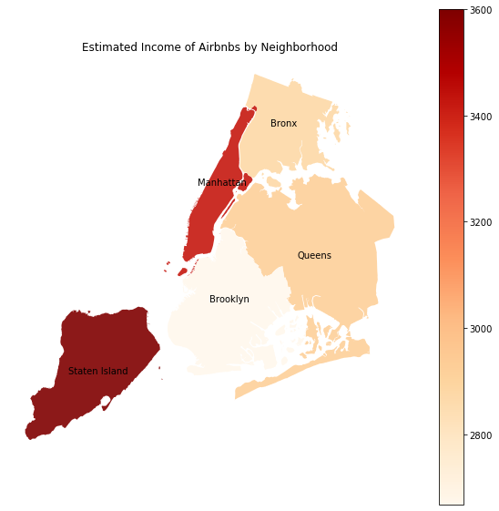

```python
inc_by_neighbor = host_income[host_income['est_income'] < 1000000].groupby('neighbourhood_group').agg({'est_income' : 'median'}).reset_index()
merge_airbnb_nyc_Inc = nyc.merge(inc_by_neighbor, on='neighbourhood_group')

fig,ax = plt.subplots(1,1, figsize=(10,10))
merge_airbnb_nyc_Inc.plot(column='est_income', cmap= 'OrRd', alpha=.9, ax=ax, legend=True)

merge_airbnb_nyc_Inc.apply(lambda x: ax.annotate(s=x.neighbourhood_group, xy=x.geometry.representative_point().coords[0], ha='center'), axis=1)
plt.title("Estimated Income of Airbnbs by Neighborhood")
plt.axis('off')
```

### The median est income for Airbnb's is highest in Staten Island but...

```
(905464.7390380859, 1075092.8783935546, 112485.76063504723, 280480.4142594267)
```

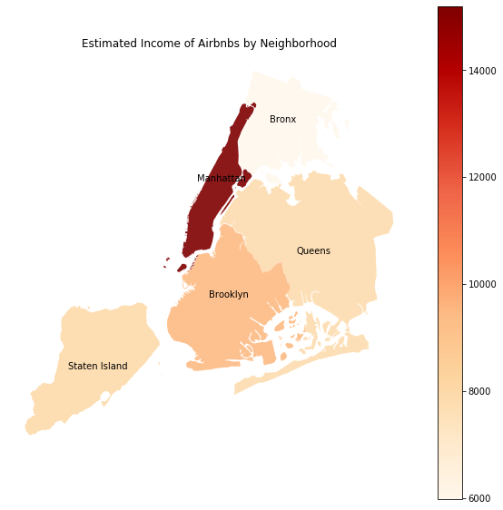

```python
inc_by_neighbor = host_income[host_income['est_income'] < 1000000].groupby('neighbourhood_group').agg({'est_income' : 'mean'}).reset_index()
merge_airbnb_nyc_Inc = nyc.merge(inc_by_neighbor, on='neighbourhood_group')

fig,ax = plt.subplots(1,1, figsize=(10,10))
merge_airbnb_nyc_Inc.plot(column='est_income', cmap= 'OrRd', alpha=.9, ax=ax, legend=True)

merge_airbnb_nyc_Inc.apply(lambda x: ax.annotate(s=x.neighbourhood_group, xy=x.geometry.representative_point().coords[0], ha='center'), axis=1)
plt.title("Estimated Income of Airbnbs by Neighborhood")
plt.axis('off')
```

### Manhattan has a lot of high earners pulling the average up, so it seems there is a lot of potential in Manhattan Airbnb's. The average number of reviews is probably being pulled down by the number of Airbnb's in the area, thus leading us to believe it is less profitable.

### Future things to look at:

#### 1. What makes a good Airbnb? Look at locations of the high earners we found, what they have in common, etc. Look into the features of the area.

#### 2. Compare prices of Airbnb's to leases housing prices and hotel prices, and determine effect of Airbnb on NYC population.